# sd6answers

**ADF test for retail sales with seasonality and trend break**

```r
dt <- read.csv("RetailSales.csv")
Retail_m <- ts(dt$Total, frequency=12, start=c(1982,4), end=c(2024,9))
logRetailSales <- window(log(aggregate(Retail_m, nfrequency=4)),
                         start=c(2000,1), end=c(2018,4))
n <- length(logRetailSales)
```

1. Simulating a time series under the unit root null and calculating the ADF test equation:

   ```r
   library(urca)
   # Set seed so the output is the same for each run
   set.seed(42)

   # Random drawing from ARIMA(0,1,0) model
   Y <- arima.sim(n=n, model=list(order=c(0,1,0)))[-1]

   # Compute ADF test with trend, print out equation
   ADF <- ur.df(Y, type="trend", lags=0)
   print(round(ADF@testreg$coefficients,4))
   ```

   ```
               Estimate Std. Error t value Pr(>|t|)
   (Intercept)   0.4032     0.3308  1.2188   0.2269
   z.lag.1      -0.0901     0.0492 -1.8313   0.0712
   tt           -0.0060     0.0067 -0.9086   0.3666
   ```

   Replicating the ADF test equation using `lm`:

   ```r
   # p: lag length in ADF test equation
   p <- 1

   # Observation indices for AR(p) model
   t <- (p+1):n

   # First difference and one lag of Y:
   DY <- Y[t]-Y[t-1]
   Y1 <- Y[t-1]

   # ADF testing equation with linear trend
   eq0 <- summary(lm(DY~Y1+t))
   print(round(eq0$coefficients,4))
   ```

   ```
               Estimate Std. Error t value Pr(>|t|)
   (Intercept)   0.4093     0.3368  1.2151   0.2283
   Y1           -0.0901     0.0492 -1.8313   0.0712
   t            -0.0060     0.0067 -0.9086   0.3666
   ```

   This implementation would be suitable for the purpose of calculating the ADF *t* statistic, noting that the `t value` matches for `z.lag.1` and `Y1` in the two pieces of output. You may notice the `(Intercept)` is slightly different – the reason is that the `ur.df` command uses $(t-1)$ for the linear trend instead of $t$. To verify:

   ```r
   # ADF testing equation with linear trend
   eq1 <- summary(lm(DY~Y1+I(t-1)))
   print(round(eq1$coefficients,4))
   ```

   ```
               Estimate Std. Error t value Pr(>|t|)
   (Intercept)   0.4032     0.3308  1.2188   0.2269
   Y1           -0.0901     0.0492 -1.8313   0.0712
   I(t - 1)     -0.0060     0.0067 -0.9086   0.3666
   ```

   There is no clear reason to use $t-1$ instead of $t$ and it makes no difference to the unit root test, so we will follow the more usual convention of using $t$.
2. Simulation code:

   ```r
   set.seed(42)
   p <- 1
   t <- (p+1):n
   reps <- 10000
   tADF <- matrix(nrow=reps, ncol=1)
   for (r in 1:reps){
     Y <- arima.sim(n=n, model=list(order=c(0,1,0)))[-1]
     DY <- Y[t]-Y[t-1]
     Y1 <- Y[t-1]
     tADF[r] <- summary(lm(DY~Y1+t))$coefficients["Y1","t value"]
   }
   ```

   1. Histogram:

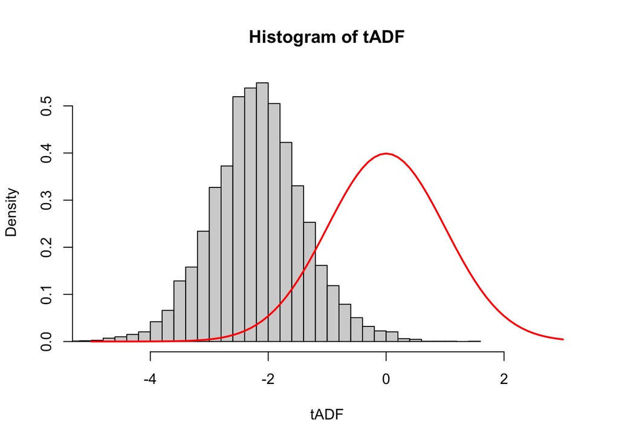

      ```r
      hist(tADF, breaks=30, freq=FALSE, xlim=c(-5,3))
      x <- seq(from=-5, to=3, by=0.1)
      lines(x, dnorm(x), col="red", lwd=2)
      ```

   2. Simulated critical values:

      ```r
      SignificanceLevels <- c(0.01, 0.05, 0.1)
      cv_sim <- quantile(tADF, probs=SignificanceLevels)
      ```

      ```
                1%     5%     10%
      cv_sim -4.075 -3.458 -3.151
      ```

   3. Comparing with `qunitroot`:

      ```r
      cv_trend <- qunitroot(p=SignificanceLevels,
                    N=n, trend="ct", statistic="t")
      ```

      ```
                  1%     5%     10%
      cv_trend -4.083 -3.470 -3.162
      ```

      The simulated critical values provide a good approximation to those from the `qunitroot` command. The latter are themselves approximations, but from a very large and sophisticated simulation exercise. Increasing the number of replications in our simulations would be expected to improve the quality of the approximation for the critical values. Large numbers of replications are required to accurately simulate from the tail of the sampling distribution (1,5,10 percentiles) which is where the critical value are obtained.
3. Simulation code:

   ```r
   library(forecast)
   p <- 1
   t <- (p+1):n

   # Setting up the X matrix of deterministic regressors
   QD <- seasonaldummy(logRetailSales)
   Time <- time(logRetailSales)
   gfc <- 2008.5
   Time_postgfc <- 1*(Time>gfc)*(Time-gfc)
   X <- cbind(Time, Time_postgfc, QD)[t,]

   reps <- 10000
   tADF <- matrix(nrow=reps, ncol=1)
   for (r in 1:reps){

     # Simulate under H0
     Y <- arima.sim(n=n, model=list(order=c(0,1,0)))[-1]

     # ADF test include X deterministics
     DY <- Y[t]-Y[t-1]
     Y1 <- Y[t-1]
     tADF[r] <- summary(lm(DY~Y1+X))$coefficients["Y1","t value"]

   }
   ```

   1. Histogram

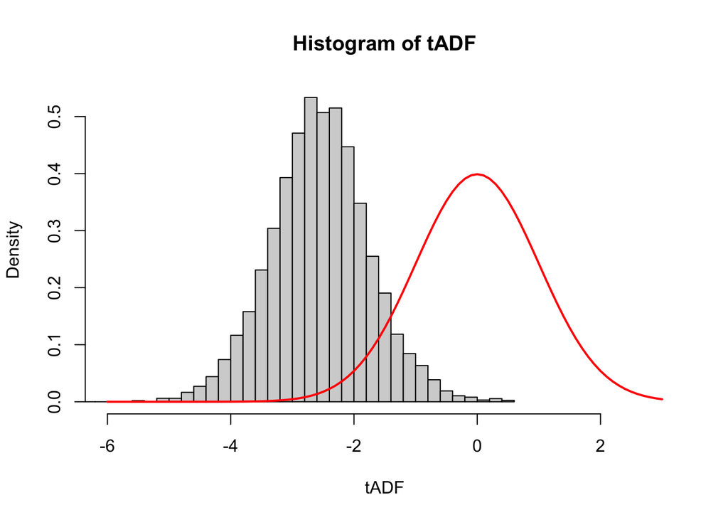

   2. Simulated critical values:

      ```r
      SignificanceLevels <- c(0.01, 0.05, 0.1)
      cv_sim <- quantile(tADF, probs=SignificanceLevels)
      ```

      ```
                1%     5%     10%
      cv_sim -4.462 -3.860 -3.553
      ```

      ```r
      p <- 3
      t <- (p+1):n

      X_ <- cbind(Time, Time_postgfc, QD)[t,]
      DY <- logRetailSales[t]-logRetailSales[t-1]
      Y1 <- logRetailSales[t-1]

      # Setting up the two lagged differences of Y
      DY1 <- logRetailSales[t-1]-logRetailSales[t-2]
      DY2 <- logRetailSales[t-2]-logRetailSales[t-3]

      ADF <- summary(lm(DY~Y1+X_+DY1+DY2))$coefficients
      print(round(ADF,4))
      ```

      ```
                     Estimate Std. Error  t value Pr(>|t|)
      (Intercept)    -27.6399     9.0084  -3.0682   0.0032
      Y1              -0.2782     0.0814  -3.4188   0.0011
      X_Time           0.0153     0.0049   3.1167   0.0027
      X_Time_postgfc  -0.0056     0.0021  -2.6592   0.0099
      X_QD.Q1         -0.2654     0.0144 -18.4255   0.0000
      X_QD.Q2         -0.1620     0.0201  -8.0655   0.0000
      X_QD.Q3         -0.0893     0.0191  -4.6759   0.0000
      DY1              0.0017     0.1172   0.0144   0.9886
      DY2              0.2171     0.1079   2.0121   0.0484
      ```

      ```r
      tstat <- ADF["Y1","t value"]
      ```

      ```
      tstat -3.4188
      ```

   2. The 5% critical value from 3(b) is $-3.860$. Since the test statistic $t=-3.4187525$ is greater than this critical, we do not reject $H_0$. i.e. we conclude the time series has a unit root.
   3. The *p*-value is calculated as follows.

      ```r
      pval <- mean(tADF<tstat)
      ```

      ```
      pval 0.1323
      ```

      The *p*-value $p=0.1323$ is *not* less than 0.05, so $H_0$ : unit root is *not* rejected.